Name:P.Surya Kumar Master Program: Data Scientist Course:Data Science Capstone Email:psurya007@gmail.com

# Project-2: Healthcare

DESCRIPTION Problem Statement NIDDK (National Institute of Diabetes and Digestive and Kidney Diseases) research creates knowledge about and treatments for the most chronic, costly, and consequential diseases. The dataset used in this project is originally from NIDDK. The objective is to predict whether or not a patient has diabetes, based on certain diagnostic measurements included in the dataset. Build a model to accurately predict whether the patients in the dataset have diabetes or not. Dataset Description The datasets consists of several medical predictor variables and one target variable (Outcome). Predictor variables includes the number of pregnancies the patient has had, their BMI, insulin level, age, and more. Variables Description Pregnancies Number of times pregnant Glucose Plasma glucose concentration in an oral glucose tolerance test BloodPressure Diastolic blood pressure (mm Hg) SkinThickness Triceps skinfold thickness (mm) Insulin Two hour serum insulin BMI Body Mass Index DiabetesPedigreeFunction Diabetes pedigree function Age Age in years Outcome Class variable (either 0 or 1). 268 of 768 values are 1, and the others are 0

# Project Task: Week_1

Data Exploration: 1. Perform descriptive analysis. Understand the variables and their corresponding values. On the columns below, a value of zero does not make sense and thus indicates missing value: • Glucose • BloodPressure • SkinThickness • Insulin • BMI 2. Visually explore these variables using histograms. Treat the missing values accordingly. 3. There are integer and float data type variables in this dataset. Create a count (frequency) plot describing the data types and the count of variables.

```python
# Import required libraries

import numpy as np
import pandas as pd
import matplotlib.pyplot as plt
%matplotlib inline
from matplotlib import style
import seaborn as sns
```

```python
pwd
```

```
'C:\\Users\\surya\\Desktop\\Simplilearn\\DataScience\\Project_2'
```

```python
Health=pd.read_csv('C:\\Users\\surya\\Desktop\\Simplilearn\\DataScience\\Project_2\\health care diabetes.csv')
Health.head()
```

|  | Pregnancies | Glucose | BloodPressure | SkinThickness | Insulin | BMI | DiabetesPedigreeFunction | Age | Outcome |
| --- | --- | --- | --- | --- | --- | --- | --- | --- | --- |
| 0 | 6 | 148 | 72 | 35 | 0 | 33.6 | 0.627 | 50 | 1 |
| 1 | 1 | 85 | 66 | 29 | 0 | 26.6 | 0.351 | 31 | 0 |
| 2 | 8 | 183 | 64 | 0 | 0 | 23.3 | 0.672 | 32 | 1 |
| 3 | 1 | 89 | 66 | 23 | 94 | 28.1 | 0.167 | 21 | 0 |
| 4 | 0 | 137 | 40 | 35 | 168 | 43.1 | 2.288 | 33 | 1 |

```python
Health.tail()
```

|  | Pregnancies | Glucose | BloodPressure | SkinThickness | Insulin | BMI | DiabetesPedigreeFunction | Age | Outcome |
| --- | --- | --- | --- | --- | --- | --- | --- | --- | --- |
| 763 | 10 | 101 | 76 | 48 | 180 | 32.9 | 0.171 | 63 | 0 |
| 764 | 2 | 122 | 70 | 27 | 0 | 36.8 | 0.340 | 27 | 0 |
| 765 | 5 | 121 | 72 | 23 | 112 | 26.2 | 0.245 | 30 | 0 |
| 766 | 1 | 126 | 60 | 0 | 0 | 30.1 | 0.349 | 47 | 1 |
| 767 | 1 | 93 | 70 | 31 | 0 | 30.4 | 0.315 | 23 | 0 |

```python
Health.shape
```

```
(768, 9)
```

```python
Health.columns
```

```
Index(['Pregnancies', 'Glucose', 'BloodPressure', 'SkinThickness', 'Insulin',
       'BMI', 'DiabetesPedigreeFunction', 'Age', 'Outcome'],
      dtype='object')
```

```python
Health.info()
```

```
<class 'pandas.core.frame.DataFrame'>
RangeIndex: 768 entries, 0 to 767
Data columns (total 9 columns):
 #   Column                    Non-Null Count  Dtype
---  ------                    --------------  -----
 0   Pregnancies               768 non-null    int64
 1   Glucose                   768 non-null    int64
 2   BloodPressure             768 non-null    int64
 3   SkinThickness             768 non-null    int64
 4   Insulin                   768 non-null    int64
 5   BMI                       768 non-null    float64
 6   DiabetesPedigreeFunction  768 non-null    float64
 7   Age                       768 non-null    int64
 8   Outcome                   768 non-null    int64
dtypes: float64(2), int64(7)
memory usage: 54.1 KB
```

```python
type(Health)
```

```
pandas.core.frame.DataFrame
```

```python
Health.isnull().sum()
```

```
Pregnancies                 0
Glucose                     0
BloodPressure               0
SkinThickness               0
Insulin                     0
BMI                         0
DiabetesPedigreeFunction    0
Age                         0
Outcome                     0
dtype: int64
```

```python
Positive = Health[Health['Outcome']==1]
Positive.head(5)
```

|  | Pregnancies | Glucose | BloodPressure | SkinThickness | Insulin | BMI | DiabetesPedigreeFunction | Age | Outcome |
| --- | --- | --- | --- | --- | --- | --- | --- | --- | --- |
| 0 | 6 | 148 | 72 | 35 | 0 | 33.6 | 0.627 | 50 | 1 |
| 2 | 8 | 183 | 64 | 0 | 0 | 23.3 | 0.672 | 32 | 1 |
| 4 | 0 | 137 | 40 | 35 | 168 | 43.1 | 2.288 | 33 | 1 |
| 6 | 3 | 78 | 50 | 32 | 88 | 31.0 | 0.248 | 26 | 1 |
| 8 | 2 | 197 | 70 | 45 | 543 | 30.5 | 0.158 | 53 | 1 |

```python
Health['Glucose'].value_counts().head(10)
```

```
100    17
99     17
129    14
125    14
111    14
106    14
95     13
108    13
105    13
102    13
Name: Glucose, dtype: int64
```

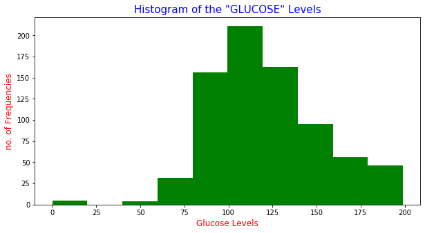

```python
# Prepare histogram for Glucose variable

plt.figure(figsize=(10,5))
plt.hist(Health['Glucose'], color='green')
plt.title('Histogram of the "GLUCOSE" Levels',c='b', size=15)
plt.xlabel('Glucose Levels',c='r',size=12)
plt.ylabel('no. of Frequencies',c='r',size=12)
plt.show()
```

```python
Health['BloodPressure'].value_counts().head(10)
```

```
70    57
74    52
68    45
78    45
72    44
64    43
80    40
76    39
60    37
0     35
Name: BloodPressure, dtype: int64
```

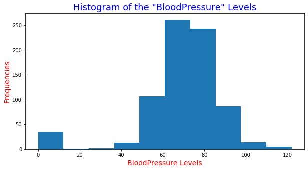

```python
# Prepare histogram for BloodPressure variable

plt.figure(figsize=(10,5))
plt.hist(Health['BloodPressure'])
plt.title('Histogram of the "BloodPressure" Levels',c='b', size=18)
plt.xlabel('BloodPressure Levels',c='r',size=14)
plt.ylabel('Frequencies',c='r',size=14)
plt.show()
```

```python
Health['SkinThickness'].value_counts().head(10)
```

```
0     227
32     31
30     27
27     23
23     22
33     20
18     20
28     20
31     19
39     18
Name: SkinThickness, dtype: int64
```

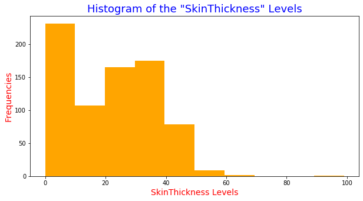

```python
# Prepare histogram for SkinThickness variable

plt.figure(figsize=(10,5))
plt.hist(Health['SkinThickness'], color='orange')
plt.title('Histogram of the "SkinThickness" Levels',c='b', size=18)
plt.xlabel('SkinThickness Levels',c='r',size=14)
plt.ylabel('Frequencies',c='r',size=14)
plt.show()
```

```python
Health['Insulin'].value_counts().head(10)
```

```
0      374
105     11
140      9
130      9
120      8
100      7
94       7
180      7
110      6
115      6
Name: Insulin, dtype: int64
```

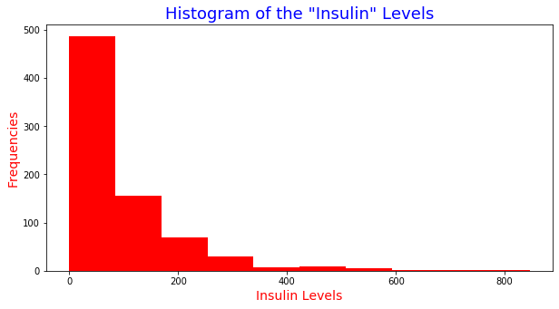

```python
# Prepare histogram for Insulin variable

plt.figure(figsize=(10,5))
plt.hist(Health['Insulin'], color='red')
plt.title('Histogram of the "Insulin" Levels',c='b', size=18)
plt.xlabel('Insulin Levels',c='r',size=14)
plt.ylabel('Frequencies',c='r',size=14)
plt.show()
```

```python
Health['BMI'].value_counts().head(10)
```

```
32.0    13
31.6    12
31.2    12
0.0     11
33.3    10
32.4    10
32.8     9
30.8     9
32.9     9
30.1     9
Name: BMI, dtype: int64
```

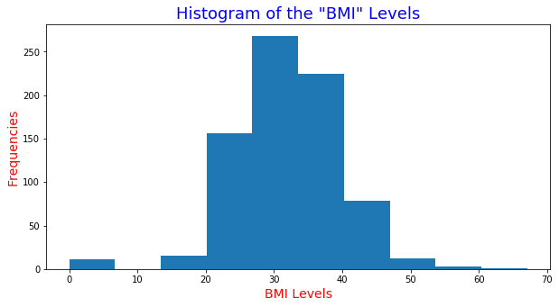

```python
# Prepare histogram for BMI variable

plt.figure(figsize=(10,5))
plt.hist(Health['BMI'])
plt.title('Histogram of the "BMI" Levels',c='b', size=18)
plt.xlabel('BMI Levels',c='r',size=14)
plt.ylabel('Frequencies',c='r',size=14)
plt.show()
```

```python
Health.describe()
```

|  | Pregnancies | Glucose | BloodPressure | SkinThickness | Insulin | BMI | DiabetesPedigreeFunction | Age | Outcome |
| --- | --- | --- | --- | --- | --- | --- | --- | --- | --- |
| count | 768.000000 | 768.000000 | 768.000000 | 768.000000 | 768.000000 | 768.000000 | 768.000000 | 768.000000 | 768.000000 |
| mean | 3.845052 | 120.894531 | 69.105469 | 20.536458 | 79.799479 | 31.992578 | 0.471876 | 33.240885 | 0.348958 |
| std | 3.369578 | 31.972618 | 19.355807 | 15.952218 | 115.244002 | 7.884160 | 0.331329 | 11.760232 | 0.476951 |
| min | 0.000000 | 0.000000 | 0.000000 | 0.000000 | 0.000000 | 0.000000 | 0.078000 | 21.000000 | 0.000000 |
| 25% | 1.000000 | 99.000000 | 62.000000 | 0.000000 | 0.000000 | 27.300000 | 0.243750 | 24.000000 | 0.000000 |
| 50% | 3.000000 | 117.000000 | 72.000000 | 23.000000 | 30.500000 | 32.000000 | 0.372500 | 29.000000 | 0.000000 |
| 75% | 6.000000 | 140.250000 | 80.000000 | 32.000000 | 127.250000 | 36.600000 | 0.626250 | 41.000000 | 1.000000 |
| max | 17.000000 | 199.000000 | 122.000000 | 99.000000 | 846.000000 | 67.100000 | 2.420000 | 81.000000 | 1.000000 |

```python
Health.describe().transpose()
```

|  | count | mean | std | min | 25% | 50% | 75% | max |
| --- | --- | --- | --- | --- | --- | --- | --- | --- |
| Pregnancies | 768.0 | 3.845052 | 3.369578 | 0.000 | 1.00000 | 3.0000 | 6.00000 | 17.00 |
| Glucose | 768.0 | 120.894531 | 31.972618 | 0.000 | 99.00000 | 117.0000 | 140.25000 | 199.00 |
| BloodPressure | 768.0 | 69.105469 | 19.355807 | 0.000 | 62.00000 | 72.0000 | 80.00000 | 122.00 |
| SkinThickness | 768.0 | 20.536458 | 15.952218 | 0.000 | 0.00000 | 23.0000 | 32.00000 | 99.00 |
| Insulin | 768.0 | 79.799479 | 115.244002 | 0.000 | 0.00000 | 30.5000 | 127.25000 | 846.00 |
| BMI | 768.0 | 31.992578 | 7.884160 | 0.000 | 27.30000 | 32.0000 | 36.60000 | 67.10 |
| DiabetesPedigreeFunction | 768.0 | 0.471876 | 0.331329 | 0.078 | 0.24375 | 0.3725 | 0.62625 | 2.42 |
| Age | 768.0 | 33.240885 | 11.760232 | 21.000 | 24.00000 | 29.0000 | 41.00000 | 81.00 |
| Outcome | 768.0 | 0.348958 | 0.476951 | 0.000 | 0.00000 | 0.0000 | 1.00000 | 1.00 |

# Project Task: Week 2

Data Exploration: 1. Check the balance of the data by plotting the count of outcomes by their value. Describe your findings and plan future course of action. 2. Create scatter charts between the pair of variables to understand the relationships. Describe your findings. 3. Perform correlation analysis. Visually explore it using a heat map.

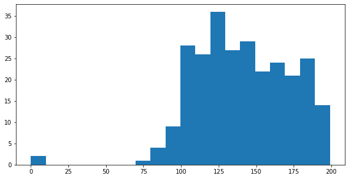

```python
plt.figure(figsize=(10,5))
plt.hist(Positive['Glucose'],histtype='stepfilled',bins=20)
```

```python
Positive['Glucose'].value_counts().head()
```

```
125    7
158    6
128    6
115    6
129    6
Name: Glucose, dtype: int64
```

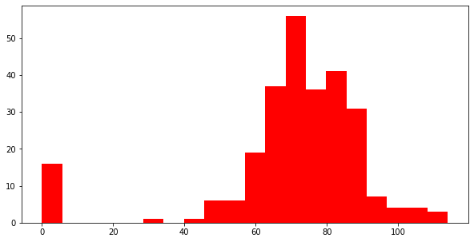

```python
plt.figure(figsize=(10,5))
plt.hist(Positive['BloodPressure'],histtype='stepfilled',bins=20, color='red')
```

```python
Positive['BloodPressure'].value_counts().head()
```

```
70    23
76    18
78    17
74    17
72    16
Name: BloodPressure, dtype: int64
```

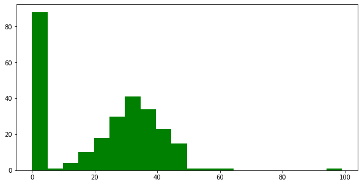

```python
plt.figure(figsize=(10,5))
plt.hist(Positive['SkinThickness'],histtype='stepfilled',bins=20,color='green')
```

```python
Positive['SkinThickness'].value_counts().head()
```

```
0     88
32    14
33     9
30     9
39     8
Name: SkinThickness, dtype: int64
```

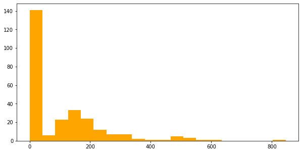

```python
plt.figure(figsize=(10,5))
plt.hist(Positive['Insulin'],histtype='stepfilled',bins=20,color='orange')
```

```python
Positive['Insulin'].value_counts().head()
```

```
0      138
130      6
180      4
156      3
175      3
Name: Insulin, dtype: int64
```

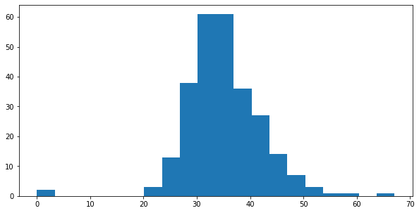

```python
plt.figure(figsize=(10,5))
plt.hist(Positive['BMI'],histtype='stepfilled',bins=20)
```

```python
Positive['BMI'].value_counts().head()
```

```
32.9    8
31.6    7
33.3    6
30.5    5
32.0    5
Name: BMI, dtype: int64
```

# Scatter plot

```python
BloodPressure = Positive['BloodPressure']
Glucose = Positive['Glucose']
SkinThickness = Positive['SkinThickness']
Insulin = Positive['Insulin']
BMI = Positive['BMI']
```

```python
BloodPressure.head()
```

```
0    72
2    64
4    40
6    50
8    70
Name: BloodPressure, dtype: int64
```

```python
Glucose.head()
```

```
0    148
2    183
4    137
6     78
8    197
Name: Glucose, dtype: int64
```

```python
Glucose.shape
```

```
(268,)
```

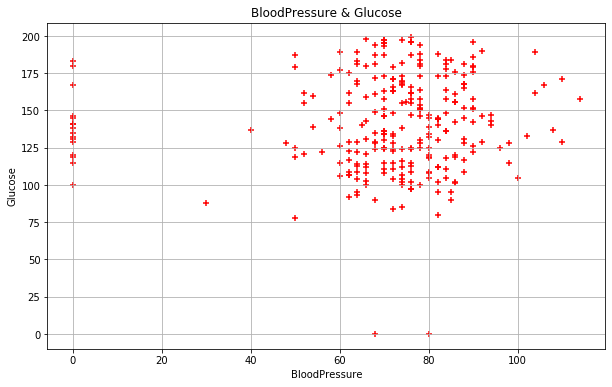

```python
plt.figure(figsize=(10,6))
plt.grid()
plt.scatter(BloodPressure, Glucose, color='r', marker='+')
plt.title('BloodPressure & Glucose')
plt.xlabel('BloodPressure')
plt.ylabel('Glucose')
plt.show()
```

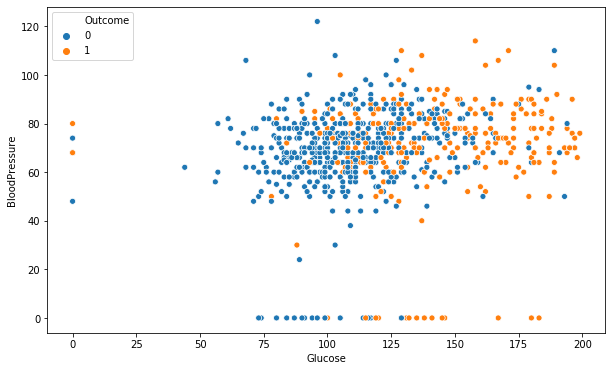

```python
plt.figure(figsize=(10,6))
sns.scatterplot(x= "Glucose" ,y= "BloodPressure",hue="Outcome",data=Health)
```

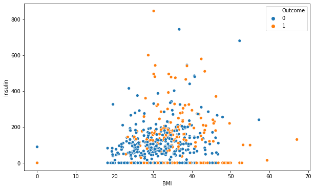

```python
plt.figure(figsize=(10,6))
sns.scatterplot(x= "BMI" ,y= "Insulin",hue="Outcome",data=Health)
```

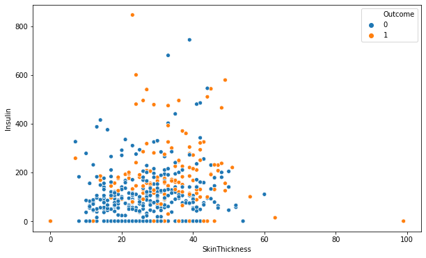

```python
plt.figure(figsize=(10,6))
sns.scatterplot(x= "SkinThickness" ,y= "Insulin",hue="Outcome", data=Health)
```

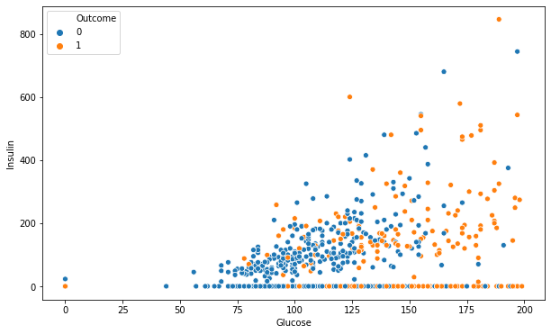

```python
plt.figure(figsize=(10,6))
sns.scatterplot(x= "Glucose" ,y= "Insulin",hue="Outcome",data=Health)
```

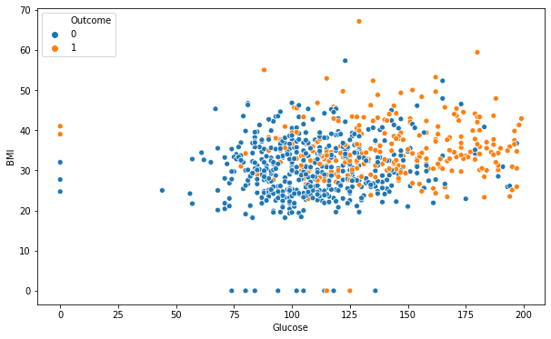

```python
plt.figure(figsize=(10,6))
sns.scatterplot(x= "Glucose" ,y= "BMI",hue="Outcome",data=Health)
```

```python
Health.columns
```

```
Index(['Pregnancies', 'Glucose', 'BloodPressure', 'SkinThickness', 'Insulin',
       'BMI', 'DiabetesPedigreeFunction', 'Age', 'Outcome'],
      dtype='object')
```

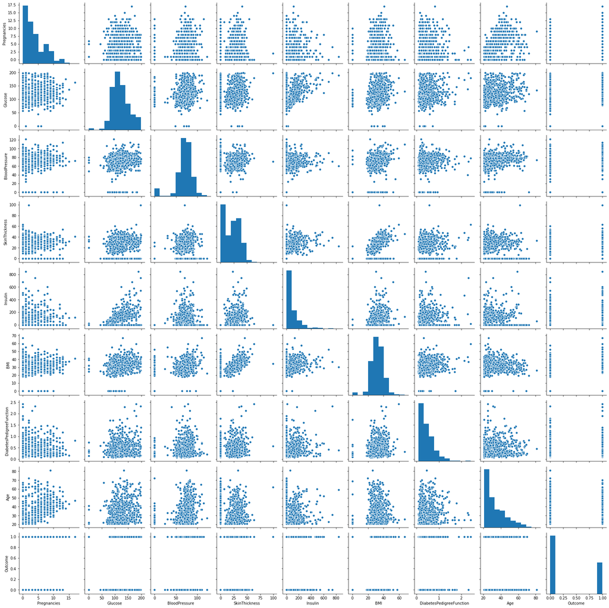

```python
sns.pairplot(Health)
```

```python
Health.columns
```

```
Index(['Pregnancies', 'Glucose', 'BloodPressure', 'SkinThickness', 'Insulin',
       'BMI', 'DiabetesPedigreeFunction', 'Age', 'Outcome'],
      dtype='object')
```

```python
Data=Health.drop(['Pregnancies','DiabetesPedigreeFunction','Age','Outcome'],axis=1)
```

```python
Data.head()
```

|  | Glucose | BloodPressure | SkinThickness | Insulin | BMI |
| --- | --- | --- | --- | --- | --- |
| 0 | 148 | 72 | 35 | 0 | 33.6 |
| 1 | 85 | 66 | 29 | 0 | 26.6 |
| 2 | 183 | 64 | 0 | 0 | 23.3 |
| 3 | 89 | 66 | 23 | 94 | 28.1 |
| 4 | 137 | 40 | 35 | 168 | 43.1 |

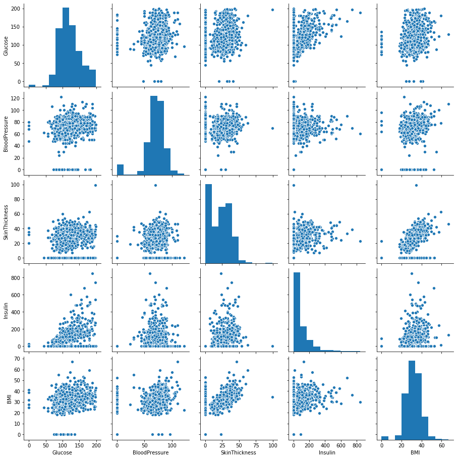

```python
sns.pairplot(Data)
```

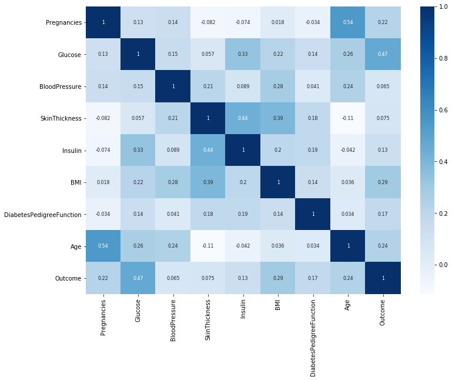

```python
# Heat map for correlation matrix

plt.figure(figsize=(12,9))
corr = Health.corr()
sns.heatmap(corr, cmap = "Blues", vmax = 1, annot_kws = {'size':8}, annot = True)
plt.show()

#vmax: value to anchor the colourmap
#annot_kws: specifies the size of values displayed in each cell
#annot = True: write the data value in each cell
```

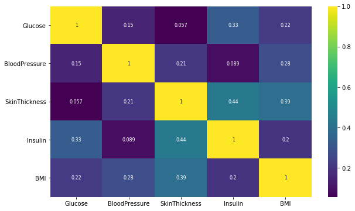

```python
# Heat map for correlation matrix

plt.figure(figsize=(10,6))
corr = Data.corr()
sns.heatmap(corr, cmap = 'viridis', vmax = 1, annot_kws = {'size':8}, annot = True)
plt.show()

#vmax: value to anchor the colourmap
#annot_kws: specifies the size of values displayed in each cell
#annot = True: write the data value in each cell
```

# Project Task: Week 3

Data Modeling: 1. Devise strategies for model building. It is important to decide the right validation framework. Express your thought process. 2. Apply an appropriate classification algorithm to build a model. Compare various models with the results from KNN algorithm.

```python
Health.head()
```

|  | Pregnancies | Glucose | BloodPressure | SkinThickness | Insulin | BMI | DiabetesPedigreeFunction | Age | Outcome |
| --- | --- | --- | --- | --- | --- | --- | --- | --- | --- |
| 0 | 6 | 148 | 72 | 35 | 0 | 33.6 | 0.627 | 50 | 1 |
| 1 | 1 | 85 | 66 | 29 | 0 | 26.6 | 0.351 | 31 | 0 |
| 2 | 8 | 183 | 64 | 0 | 0 | 23.3 | 0.672 | 32 | 1 |
| 3 | 1 | 89 | 66 | 23 | 94 | 28.1 | 0.167 | 21 | 0 |
| 4 | 0 | 137 | 40 | 35 | 168 | 43.1 | 2.288 | 33 | 1 |

```python
features = Health.iloc[:,[0,1,2,3,4,5,6,7]].values
label = Health.iloc[:,8].values
```

```python
features.shape
```

```
(768, 8)
```

```python
label.shape
```

```
(768,)
```

```python
#Train test split

from sklearn.model_selection import train_test_split
X_train,X_test,y_train,y_test = train_test_split(features,
                                                label,
                                                test_size=0.2,
                                                random_state =10)
```

```python
#Create model

from sklearn.linear_model import LogisticRegression
model = LogisticRegression()
model.fit(X_train,y_train)
```

```
LogisticRegression(C=1.0, class_weight=None, dual=False, fit_intercept=True,
                   intercept_scaling=1, l1_ratio=None, max_iter=100,
                   multi_class='auto', n_jobs=None, penalty='l2',
                   random_state=None, solver='lbfgs', tol=0.0001, verbose=0,
                   warm_start=False)
```

```python
print(model.score(X_train,y_train))
print(model.score(X_test,y_test))
```

```
0.7719869706840391
0.7662337662337663
```

```python
from sklearn.metrics import confusion_matrix
cm = confusion_matrix(label,model.predict(features))
cm
```

```
array([[446,  54],
       [122, 146]], dtype=int64)
```

```python
from sklearn.metrics import classification_report
print(classification_report(label,model.predict(features)))
```

```
              precision    recall  f1-score   support

           0       0.79      0.89      0.84       500
           1       0.73      0.54      0.62       268

    accuracy                           0.77       768
   macro avg       0.76      0.72      0.73       768
weighted avg       0.77      0.77      0.76       768
```

```
AUC: 0.837
```

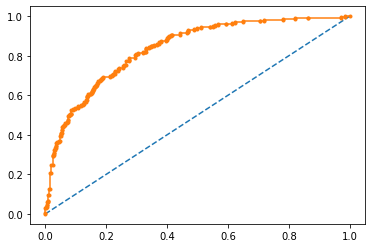

```python
#Preparing ROC Curve (Receiver Operating Characteristics Curve)
from sklearn.metrics import roc_curve
from sklearn.metrics import roc_auc_score

# predict probabilities
probs = model.predict_proba(features)
# keep probabilities for the positive outcome only
probs = probs[:, 1]
# calculate AUC
auc = roc_auc_score(label, probs)
print('AUC: %.3f' % auc)
# calculate roc curve
fpr, tpr, thresholds = roc_curve(label, probs)
# plot no skill
plt.plot([0, 1], [0, 1], linestyle='--')
# plot the roc curve for the model
plt.plot(fpr, tpr, marker='.')
```

```python
#Applying Decission Tree Classifier

from sklearn.tree import DecisionTreeClassifier
model3 = DecisionTreeClassifier(max_depth=5)
model3.fit(X_train,y_train)
```

```
DecisionTreeClassifier(ccp_alpha=0.0, class_weight=None, criterion='gini',
                       max_depth=5, max_features=None, max_leaf_nodes=None,
                       min_impurity_decrease=0.0, min_impurity_split=None,
                       min_samples_leaf=1, min_samples_split=2,
                       min_weight_fraction_leaf=0.0, presort='deprecated',
                       random_state=None, splitter='best')
```

```python
model3.score(X_train,y_train)
```

```
0.8289902280130294
```

```python
model3.score(X_test,y_test)
```

```
0.7597402597402597
```

```python
#Applying Random Forest

from sklearn.ensemble import RandomForestClassifier
model4 = RandomForestClassifier(n_estimators=11)
model4.fit(X_train,y_train)
```

```
RandomForestClassifier(bootstrap=True, ccp_alpha=0.0, class_weight=None,
                       criterion='gini', max_depth=None, max_features='auto',
                       max_leaf_nodes=None, max_samples=None,
                       min_impurity_decrease=0.0, min_impurity_split=None,
                       min_samples_leaf=1, min_samples_split=2,
                       min_weight_fraction_leaf=0.0, n_estimators=11,
                       n_jobs=None, oob_score=False, random_state=None,
                       verbose=0, warm_start=False)
```

```python
model4.score(X_train,y_train)
```

```
0.9869706840390879
```

```python
model4.score(X_test,y_test)
```

```
0.7142857142857143
```

```python
#Support Vector Classifier

from sklearn.svm import SVC
model5 = SVC(kernel='rbf',gamma='auto')
model5.fit(X_train,y_train)
```

```
SVC(C=1.0, break_ties=False, cache_size=200, class_weight=None, coef0=0.0,
    decision_function_shape='ovr', degree=3, gamma='auto', kernel='rbf',
    max_iter=-1, probability=False, random_state=None, shrinking=True,
    tol=0.001, verbose=False)
```

```python
model5.score(X_train,y_train)
```

```
1.0
```

```python
model5.score(X_test,y_test)
```

```
0.6168831168831169
```

```python
#Applying K-NN
from sklearn.neighbors import KNeighborsClassifier
model2 = KNeighborsClassifier(n_neighbors=7,metric='minkowski',p = 2)
model2.fit(X_train,y_train)
```

```
KNeighborsClassifier(algorithm='auto', leaf_size=30, metric='minkowski',
                     metric_params=None, n_jobs=None, n_neighbors=7, p=2,
                     weights='uniform')
```

```
AUC: 0.836
True Positive Rate - [0.         0.06716418 0.23880597 0.44776119 0.60074627 0.75373134
 0.88059701 0.98507463 1.        ], False Positive Rate - [0.    0.    0.02  0.056 0.12  0.248 0.428 0.668 1.   ] Thresholds - [2.         1.         0.85714286 0.71428571 0.57142857 0.42857143
 0.28571429 0.14285714 0.        ]
```

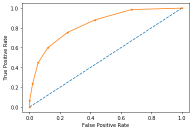

```python
#Preparing ROC Curve (Receiver Operating Characteristics Curve)
from sklearn.metrics import roc_curve
from sklearn.metrics import roc_auc_score

# predict probabilities
probs = model2.predict_proba(features)
# keep probabilities for the positive outcome only
probs = probs[:, 1]
# calculate AUC
auc = roc_auc_score(label, probs)
print('AUC: %.3f' % auc)
# calculate roc curve
fpr, tpr, thresholds = roc_curve(label, probs)
print("True Positive Rate - {}, False Positive Rate - {} Thresholds - {}".format(tpr,fpr,thresholds))
# plot no skill
plt.plot([0, 1], [0, 1], linestyle='--')
# plot the roc curve for the model
plt.plot(fpr, tpr, marker='.')
plt.xlabel("False Positive Rate")
plt.ylabel("True Positive Rate")
```

```
f1=0.624 auc=0.726 ap=0.727
```

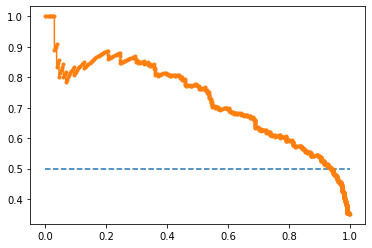

```python
#Precision Recall Curve for Logistic Regression

from sklearn.metrics import precision_recall_curve
from sklearn.metrics import f1_score
from sklearn.metrics import auc
from sklearn.metrics import average_precision_score
# predict probabilities
probs = model.predict_proba(features)
# keep probabilities for the positive outcome only
probs = probs[:, 1]
# predict class values
yhat = model.predict(features)
# calculate precision-recall curve
precision, recall, thresholds = precision_recall_curve(label, probs)
# calculate F1 score
f1 = f1_score(label, yhat)
# calculate precision-recall AUC
auc = auc(recall, precision)
# calculate average precision score
ap = average_precision_score(label, probs)
print('f1=%.3f auc=%.3f ap=%.3f' % (f1, auc, ap))
# plot no skill
plt.plot([0, 1], [0.5, 0.5], linestyle='--')
# plot the precision-recall curve for the model
plt.plot(recall, precision, marker='.')
```

```
f1=0.658 auc=0.752 ap=0.709
```

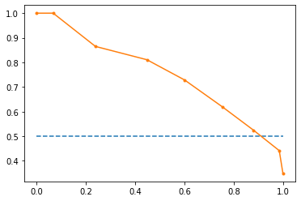

```python
#Precision Recall Curve for KNN

from sklearn.metrics import precision_recall_curve
from sklearn.metrics import f1_score
from sklearn.metrics import auc
from sklearn.metrics import average_precision_score
# predict probabilities
probs = model2.predict_proba(features)
# keep probabilities for the positive outcome only
probs = probs[:, 1]
# predict class values
yhat = model2.predict(features)
# calculate precision-recall curve
precision, recall, thresholds = precision_recall_curve(label, probs)
# calculate F1 score
f1 = f1_score(label, yhat)
# calculate precision-recall AUC
auc = auc(recall, precision)
# calculate average precision score
ap = average_precision_score(label, probs)
print('f1=%.3f auc=%.3f ap=%.3f' % (f1, auc, ap))
# plot no skill
plt.plot([0, 1], [0.5, 0.5], linestyle='--')
# plot the precision-recall curve for the model
plt.plot(recall, precision, marker='.')
```

```
f1=0.708 auc=0.800 ap=0.761
```

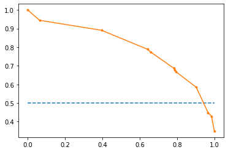

```python
#Precision Recall Curve for Decission Tree Classifier

from sklearn.metrics import precision_recall_curve
from sklearn.metrics import f1_score
from sklearn.metrics import auc
from sklearn.metrics import average_precision_score
# predict probabilities
probs = model3.predict_proba(features)
# keep probabilities for the positive outcome only
probs = probs[:, 1]
# predict class values
yhat = model3.predict(features)
# calculate precision-recall curve
precision, recall, thresholds = precision_recall_curve(label, probs)
# calculate F1 score
f1 = f1_score(label, yhat)
# calculate precision-recall AUC
auc = auc(recall, precision)
# calculate average precision score
ap = average_precision_score(label, probs)
print('f1=%.3f auc=%.3f ap=%.3f' % (f1, auc, ap))
# plot no skill
plt.plot([0, 1], [0.5, 0.5], linestyle='--')
# plot the precision-recall curve for the model
plt.plot(recall, precision, marker='.')
```

```
f1=0.901 auc=0.958 ap=0.948
```

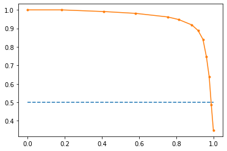

```python
#Precision Recall Curve for Random Forest

from sklearn.metrics import precision_recall_curve
from sklearn.metrics import f1_score
from sklearn.metrics import auc
from sklearn.metrics import average_precision_score
# predict probabilities
probs = model4.predict_proba(features)
# keep probabilities for the positive outcome only
probs = probs[:, 1]
# predict class values
yhat = model4.predict(features)
# calculate precision-recall curve
precision, recall, thresholds = precision_recall_curve(label, probs)
# calculate F1 score
f1 = f1_score(label, yhat)
# calculate precision-recall AUC
auc = auc(recall, precision)
# calculate average precision score
ap = average_precision_score(label, probs)
print('f1=%.3f auc=%.3f ap=%.3f' % (f1, auc, ap))
# plot no skill
plt.plot([0, 1], [0.5, 0.5], linestyle='--')
# plot the precision-recall curve for the model
plt.plot(recall, precision, marker='.')
```